# Group Assignment 1 - Cars

Instructions: During the class session, you will be divided in to groups for this exercise. This exercise will not be graded but will account for extra credit.

Use the provided dataset to answer the following questions:

1. Does the dataset have any missing information?
2. Does the dataset have any outliers?
3. Which of the variables within the dataset are not normally distributed?
4. Show the descriptive statistics of all the continuous variables within the dataset.

#### Group Members

1. Remmy Bisimbeko - B26099 - J24M19/011 My GitHub - https://github.com/RemmyBisimbeko/Data-Science

Recommended Libraries

```python
import pandas as pd
import numpy as np
import matplotlib.pyplot as plt
```

Read Excel File

```python
df = pd.read_excel("Data Sets/Assignment1_Cars-1.xlsx")
```

Display first five rows of data

```python
df.head()
```

|  | model | mpg | cyl | disp | hp | drat | wt | qsec | vs | am | gear | carb |
| --- | --- | --- | --- | --- | --- | --- | --- | --- | --- | --- | --- | --- |
| 0 | Mazda RX4 | 21.0 | 6 | 160.0 | 110 | 3.90 | 2.620 | 16.46 | 0 | 1 | 4 | 4 |
| 1 | Mazda RX4 Wag | 21.0 | 6 | 160.0 | 110 | 3.90 | 2.875 | 17.02 | 0 | 1 | 4 | 4 |
| 2 | Datsun 710 | 22.8 | 4 | 108.0 | 93 | 3.85 | 2.320 | 18.61 | 1 | 1 | 4 | 1 |
| 3 | Hornet 4 Drive | 21.4 | 6 | 258.0 | 110 | 3.08 | 3.215 | 19.44 | 1 | 0 | 3 | 1 |
| 4 | Hornet Sportabout | 18.7 | 8 | 360.0 | 175 | 3.15 | 3.440 | 17.02 | 0 | 0 | 3 | 2 |

Display bottom five rows (optional)

```python
df.tail()
```

|  | model | mpg | cyl | disp | hp | drat | wt | qsec | vs | am | gear | carb |
| --- | --- | --- | --- | --- | --- | --- | --- | --- | --- | --- | --- | --- |
| 58 | Acura | 21.4 | 4 | 121.0 | 109 | 4.11 | 2.78 | 18.6 | 1 | 1 | 4 | 2 |
| 59 | Toyota Tacoma | 40.6 | 2 | 75.7 | 52 | 4.93 | 17.02 | 0.0 | 0 | 3 | 2 | 1 |
| 60 | GMC Sierra | 22.8 | 4 | 140.8 | 95 | 3.92 | 3.15 | 22.9 | 1 | 0 | 4 | 2 |
| 61 | Nissan Xtrail | 17.3 | 8 | 275.8 | 180 | 3.07 | 3.73 | 17.6 | 0 | 0 | 3 | 3 |
| 62 | Merc C-class | 15.2 | 8 | 275.8 | 180 | 3.07 | 3.78 | 18.0 | 0 | 0 | 3 | 3 |

What is the Shape of our Data frame? (rows, cols)

```python
df.shape
```

```
(63, 12)
```

Column Names

```python
df.columns
```

```
Index(['model', 'mpg', 'cyl', 'disp', 'hp', 'drat', 'wt', 'qsec', 'vs', 'am',
       'gear', 'carb'],
      dtype='object')
```

Data types of each column

```python
df.dtypes
```

```
model     object
mpg      float64
cyl        int64
disp     float64
hp         int64
drat     float64
wt       float64
qsec     float64
vs         int64
am         int64
gear       int64
carb       int64
dtype: object
```

More information on the Data Frame

```python
df.info()
```

```
<class 'pandas.core.frame.DataFrame'>
RangeIndex: 63 entries, 0 to 62
Data columns (total 12 columns):
 #   Column  Non-Null Count  Dtype
---  ------  --------------  -----
 0   model   63 non-null     object
 1   mpg     63 non-null     float64
 2   cyl     63 non-null     int64
 3   disp    63 non-null     float64
 4   hp      63 non-null     int64
 5   drat    63 non-null     float64
 6   wt      63 non-null     float64
 7   qsec    63 non-null     float64
 8   vs      63 non-null     int64
 9   am      63 non-null     int64
 10  gear    63 non-null     int64
 11  carb    63 non-null     int64
dtypes: float64(5), int64(6), object(1)
memory usage: 6.0+ KB
```

Describe the Data

```python
df.describe()
```

|  | mpg | cyl | disp | hp | drat | wt | qsec | vs | am | gear | carb |
| --- | --- | --- | --- | --- | --- | --- | --- | --- | --- | --- | --- |
| count | 63.000000 | 63.000000 | 63.000000 | 63.000000 | 63.000000 | 63.000000 | 63.00000 | 63.000000 | 63.000000 | 63.000000 | 63.000000 |
| mean | 20.207937 | 6.190476 | 234.887302 | 149.285714 | 3.594286 | 3.758873 | 17.36127 | 0.396825 | 0.428571 | 3.619048 | 2.825397 |
| std | 6.755172 | 1.924856 | 122.607423 | 68.567703 | 0.558678 | 2.590846 | 3.71618 | 0.493169 | 0.665129 | 0.791662 | 1.571312 |
| min | 10.400000 | 2.000000 | 71.100000 | 52.000000 | 2.760000 | 1.513000 | 0.00000 | 0.000000 | 0.000000 | 2.000000 | 1.000000 |
| 25% | 15.200000 | 4.000000 | 130.900000 | 95.000000 | 3.075000 | 2.780000 | 16.87000 | 0.000000 | 0.000000 | 3.000000 | 2.000000 |
| 50% | 18.700000 | 6.000000 | 225.000000 | 150.000000 | 3.690000 | 3.440000 | 17.60000 | 0.000000 | 0.000000 | 3.000000 | 2.000000 |
| 75% | 22.800000 | 8.000000 | 334.000000 | 180.000000 | 3.920000 | 3.780000 | 18.90000 | 1.000000 | 1.000000 | 4.000000 | 4.000000 |
| max | 40.600000 | 8.000000 | 472.000000 | 335.000000 | 4.930000 | 17.020000 | 22.90000 | 1.000000 | 3.000000 | 5.000000 | 8.000000 |

My Observations are as follows: -We have 63 Vehicles -Highest Miles per gallon for all cars is 40.6

QN 1. Does the dataset have any missing information?

```python
df.isnull()
```

|  | model | mpg | cyl | disp | hp | drat | wt | qsec | vs | am | gear | carb |
| --- | --- | --- | --- | --- | --- | --- | --- | --- | --- | --- | --- | --- |
| 0 | False | False | False | False | False | False | False | False | False | False | False | False |
| 1 | False | False | False | False | False | False | False | False | False | False | False | False |
| 2 | False | False | False | False | False | False | False | False | False | False | False | False |
| 3 | False | False | False | False | False | False | False | False | False | False | False | False |
| 4 | False | False | False | False | False | False | False | False | False | False | False | False |
| ... | ... | ... | ... | ... | ... | ... | ... | ... | ... | ... | ... | ... |
| 58 | False | False | False | False | False | False | False | False | False | False | False | False |
| 59 | False | False | False | False | False | False | False | False | False | False | False | False |
| 60 | False | False | False | False | False | False | False | False | False | False | False | False |
| 61 | False | False | False | False | False | False | False | False | False | False | False | False |
| 62 | False | False | False | False | False | False | False | False | False | False | False | False |

63 rows × 12 columns

How many are they?

```python
df.isnull().sum()
```

```
model    0
mpg      0
cyl      0
disp     0
hp       0
drat     0
wt       0
qsec     0
vs       0
am       0
gear     0
carb     0
dtype: int64
```

Data Set appears to have no missing values!

QN 2. Does the dataset have any outliers?

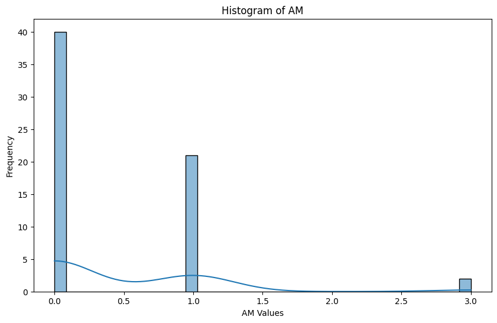

```python
# Using a Histogram to Visualise the Data
import seaborn as sns

plt.figure(figsize=(10,6))
sns.histplot(df['am'], bins=35, kde=True)
plt.title('Histogram of AM')
plt.xlabel('AM Values')
plt.ylabel('Frequency')
plt.show()
```

```python
# Detect the Outliers Using the Z-Score Approach
import scipy.stats as stats

zscores = stats.zscore(df['am'])
threshold = 3
outliers = np.where(np.abs(zscores) > threshold)[0]

print("Outliers:", outliers)
```

```
Outliers: [32 59]
```

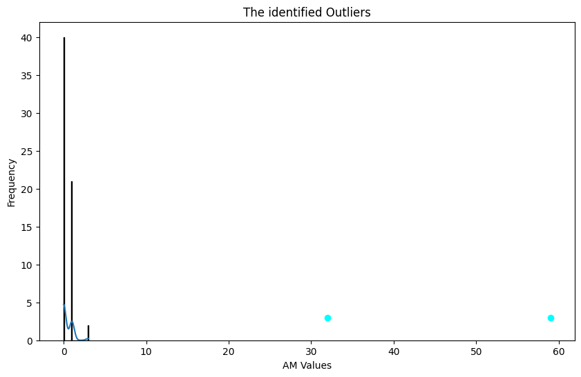

```python
# Visualise the Outliers
plt.figure(figsize=(10, 6))
sns.histplot(df['am'], bins=35, kde=True)
plt.scatter(outliers, df['am'].iloc[outliers], color='cyan', label='Outliers')
plt.title('The Identified Outliers')
plt.xlabel('AM Values')
plt.ylabel('Frequency')
plt.show()
```

QN 3. Which of the variables within the dataset are not normally distributed?

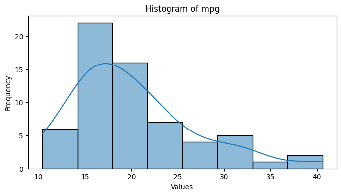

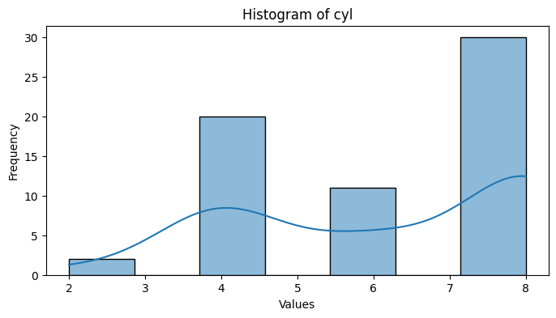

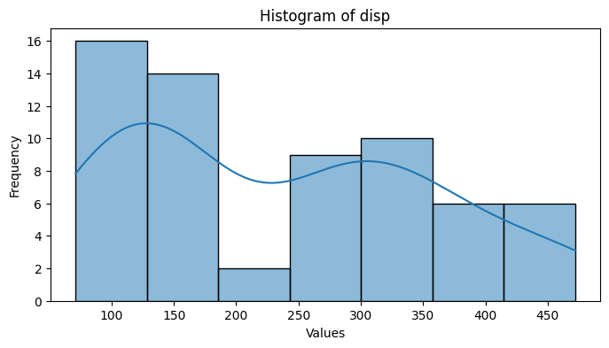

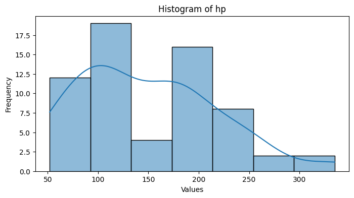

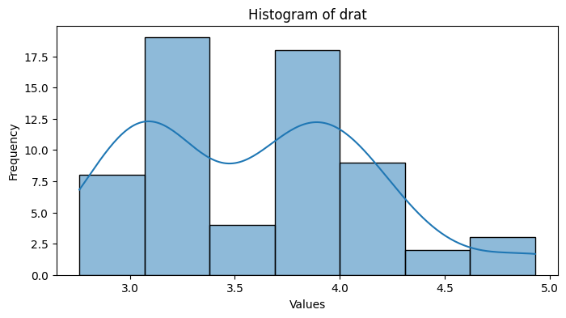

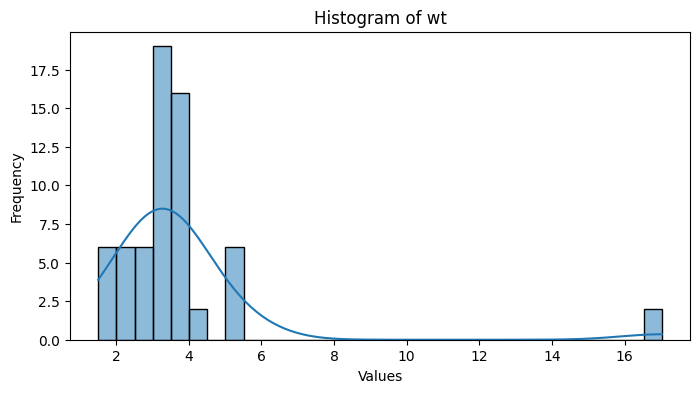

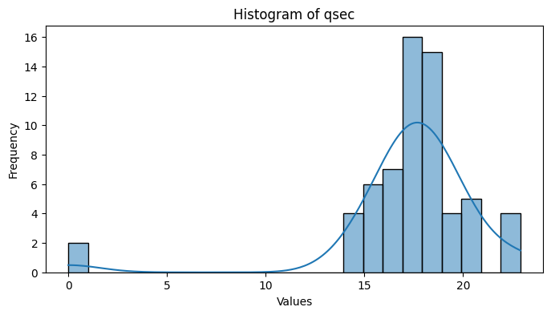

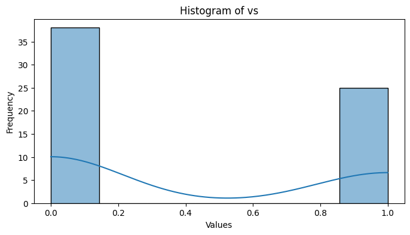

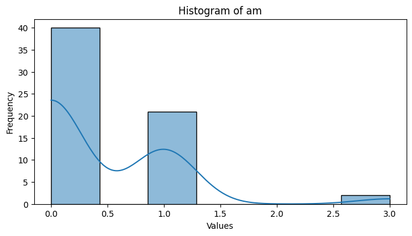

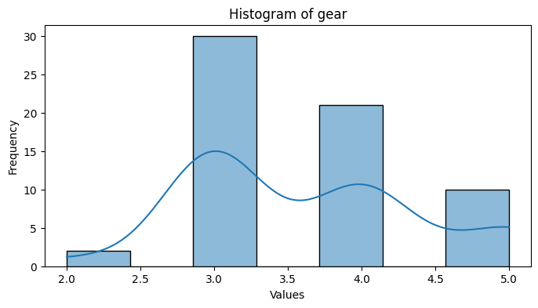

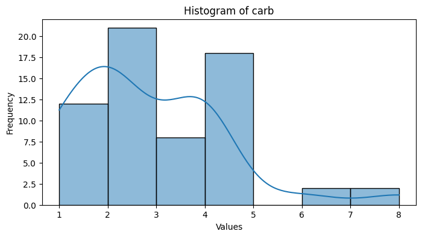

```python
# Remove non-numeric columns
numeric_columns = df.select_dtypes(include=[np.number]).columns
df_numeric = df[numeric_columns]

# Visual inspection of histograms
for column in df_numeric.columns:
    plt.figure(figsize=(8, 4))
    sns.histplot(df_numeric[column], kde=True)
    plt.title(f'Histogram of {column}')
    plt.xlabel('Values')
    plt.ylabel('Frequency')
    plt.show()
```

```python
# Using the Shapiro-Wilk test for normality
from scipy.stats import shapiro

# Shapiro-Wilk test
non_normal_variables = []
for column in df_numeric.columns:
    stat, p = shapiro(df_numeric[column])
    alpha = 0.05
    if p < alpha:
        non_normal_variables.append(column)
        print(f'{column} is not normally distributed (p-value={p})')
    else:
        print(f'{column} is normally distributed (p-value={p})')

print("\nVariables not normally distributed:", non_normal_variables)
```

```
mpg is not normally distributed (p-value=0.00021498681772254538)
cyl is not normally distributed (p-value=1.9259465725125302e-08)
disp is not normally distributed (p-value=0.0005896648328323517)
hp is not normally distributed (p-value=0.004189709579620521)
drat is not normally distributed (p-value=0.001560451108193203)
wt is not normally distributed (p-value=1.5314964146613204e-13)
qsec is not normally distributed (p-value=9.89061646923088e-11)
vs is not normally distributed (p-value=1.7410261772405094e-11)
am is not normally distributed (p-value=1.795177884425708e-11)
gear is not normally distributed (p-value=3.553517270238008e-07)
carb is not normally distributed (p-value=1.5340614007820725e-06)

Variables not normally distributed: ['mpg', 'cyl', 'disp', 'hp', 'drat', 'wt', 'qsec', 'vs', 'am', 'gear', 'carb']
```

QN 4. Show the descriptive statistics of all the continuous variables within the dataset.

```python
# Display descriptive statistics of continuous variables
continuous_variables = df.select_dtypes(include=['number'])
print(continuous_variables.describe())
```

```
             mpg        cyl        disp          hp       drat         wt  \
count  63.000000  63.000000   63.000000   63.000000  63.000000  63.000000
mean   20.207937   6.190476  234.887302  149.285714   3.594286   3.758873
std     6.755172   1.924856  122.607423   68.567703   0.558678   2.590846
min    10.400000   2.000000   71.100000   52.000000   2.760000   1.513000
25%    15.200000   4.000000  130.900000   95.000000   3.075000   2.780000
50%    18.700000   6.000000  225.000000  150.000000   3.690000   3.440000
75%    22.800000   8.000000  334.000000  180.000000   3.920000   3.780000
max    40.600000   8.000000  472.000000  335.000000   4.930000  17.020000

           qsec         vs         am       gear       carb
count  63.00000  63.000000  63.000000  63.000000  63.000000
mean   17.36127   0.396825   0.428571   3.619048   2.825397
std     3.71618   0.493169   0.665129   0.791662   1.571312
min     0.00000   0.000000   0.000000   2.000000   1.000000
25%    16.87000   0.000000   0.000000   3.000000   2.000000
50%    17.60000   0.000000   0.000000   3.000000   2.000000
75%    18.90000   1.000000   1.000000   4.000000   4.000000
max    22.90000   1.000000   3.000000   5.000000   8.000000
```

##### Sources:

https://www.kaggle.com/code/rtatman/data-cleaning-challenge-outliers https://github.com/ipython/ipython https://etna-docs.netlify.app/tutorials/outliers.html https://pythonguides.com/scipy-stats-zscore/ https://www.statology.org/z-score-python/ https://www.geeksforgeeks.org/scipy-stats-zscore-function-python/ https://docs.scipy.org/doc/scipy/reference/generated/scipy.stats.zscore.html

My Git Hub Repo https://github.com/RemmyBisimbeko/Data-Science https://www.kaggle.com/remmybisimbeko